# Practical Machine Learning Course Project

Marc Paelinck

September 14, 2016

## 1. Analyzing and preprocessing the data

### Load the Caret package and read the data

```r
library(caret)
training <- read.csv("D:/Documents/Cursussen/Coursera/Practical Machine Learning/Week4/pml-training.csv", na=c("#DIV/0!","","NA"))
testing <- read.csv("D:/Documents/Cursussen/Coursera/Practical Machine Learning/Week4/pml-testing.csv")
```

Note that I translate the value `#DIV/0!` into N/A. This value occurs in one of the columns and might otherwise cause problems.

### Split the data

The pml-testing.csv file only contains 20 observations and doesn’t contain a classe column, so it is not suited to evaluate the out of sample error. We will therfore split a validation data set from the training data.

```r
inTrain <- createDataPartition(y=training$classe, p=0.75, list=FALSE)
training.train = training[inTrain,]
training.test = training[-inTrain,]
```

It is good practice to only use the training data set for data analysis. So we will use the `training.train` data set in the following analysis.

### First columns differ from the rest

The first seven columns seem to contain a different type of data than the remaining columns.

```r
summary(training.train[,1:7])
```

```
##        X            user_name    raw_timestamp_part_1 raw_timestamp_part_2
##  Min.   :    2   adelmo  :2885   Min.   :1.322e+09    Min.   :   294
##  1st Qu.: 4913   carlitos:2371   1st Qu.:1.323e+09    1st Qu.:252291
##  Median : 9833   charles :2635   Median :1.323e+09    Median :498782
##  Mean   : 9815   eurico  :2313   Mean   :1.323e+09    Mean   :500687
##  3rd Qu.:14716   jeremy  :2577   3rd Qu.:1.323e+09    3rd Qu.:752277
##  Max.   :19622   pedro   :1937   Max.   :1.323e+09    Max.   :998801
##
##           cvtd_timestamp new_window    num_window
##  28/11/2011 14:14:1143   no :14403   Min.   :  1.0
##  05/12/2011 11:24:1134   yes:  315   1st Qu.:224.0
##  05/12/2011 11:25:1102               Median :422.0
##  30/11/2011 17:11:1082               Mean   :431.2
##  02/12/2011 14:57:1021               3rd Qu.:645.0
##  02/12/2011 13:34:1018               Max.   :864.0
##  (Other)         :8218
```

The first column a row numbering, which we can check with the following statement.

```r
sum(training.train$X==as.numeric(row.names(training.train))) == nrow(training.train)
```

```
## [1] TRUE
```

The tested person’s name is not a suitable predictor, this would make the model too specific (only applicable for the tested persons).  
The date stamp might be useful if we wanted to use the progress of a person as a predictor. However discarding this information would make the model more generic by also enabling to make a prediction for persons without any measuring history, so for the time being we will discard all columns containing date and time window information.

```r
training.train <- training.train[,-c(1:7)]
```

### Columns with large number of N/A values

Next, it appears that a large number of columns contain N/A values. We will plot a histogram in order to find out how these values are distributed over the columns.

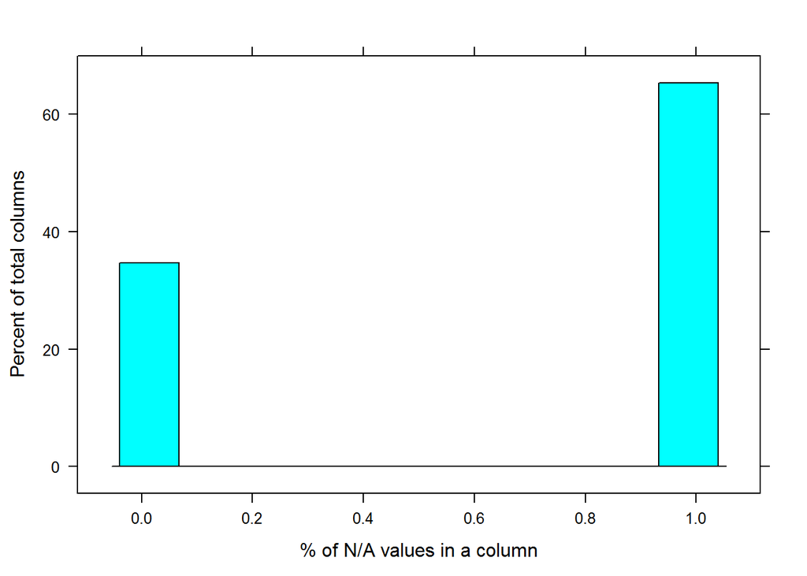

```r
NA_values <- sapply(training.train, function(x) sum(is.na(x)))/nrow(training.train)
histogram(NA_values, nint=10, xlab="% of N/A values in a column", ylab="Percent of total columns")
```

More than 60% of the columns have over 90% N/A values. We will remove these columns.

```r
training.train <- training.train[,NA_values<.5]
```

### Correlated columns

Create a covariance matrix and set the lower triangular part of the matrix to zero in order to remove duplicate column pairs.

```r
M<-abs(cor(training.train[,-which(names(training.train)==c("classe"))]))
M[lower.tri(M,diag=TRUE)] <- 0
```

Now make a list of the most correlated columns

```r
select <- data.frame(which(M>0.75, arr.ind=T), row.names=NULL)
covar <- data.frame(cbind(col1=rownames(M[select$row,]), col2=colnames(M[,select$col])))
covar$cov <- M[which(M>0.75, arr.ind=T)]
covar <- covar[order(-covar[,3]),]
covar
```

```
##                    col1              col2       cov
## 7             roll_belt      accel_belt_z 0.9920028
## 22     gyros_dumbbell_x  gyros_dumbbell_z 0.9841607
## 2             roll_belt  total_accel_belt 0.9810502
## 9      total_accel_belt      accel_belt_z 0.9749827
## 4            pitch_belt      accel_belt_x 0.9655661
## 31     gyros_dumbbell_z   gyros_forearm_z 0.9493539
## 30     gyros_dumbbell_x   gyros_forearm_z 0.9350780
## 10         accel_belt_y      accel_belt_z 0.9334629
## 6      total_accel_belt      accel_belt_y 0.9277289
## 5             roll_belt      accel_belt_y 0.9254027
## 14          gyros_arm_x       gyros_arm_y 0.9178332
## 12         accel_belt_x     magnet_belt_x 0.8910950
## 11           pitch_belt     magnet_belt_x 0.8816262
## 32      gyros_forearm_y   gyros_forearm_z 0.8686058
```

[output cut: 19 more lines]

Note that not all models are sensitive to covariated variables, so it is possible that we will not need this information.

## 2. Modeling

### Set the seed

```r
set.seed(34654)
```

We will try several models and will keep track of the computer time used to train each model.

### Tree model

We will first try a tree model. This model is relatively efficient in terms of computer resource usage.

```r
startClock <- proc.time() # Time the training session
modelFitTree <- train(classe ~., method="rpart", data=training.train)
durationTree <- proc.time() - startClock
confusionTree <- table(predict=predict(modelFitTree, training.test), actual=training.test$classe)
print(durationTree)
```

```
##    user  system elapsed
##   14.69    0.58   15.43
```

```r
confusionMatrix(confusionTree)
```

```
## Confusion Matrix and Statistics
##
##        actual
## predict    A    B    C    D    E
##       A 1263  379  397  349  114
##       B   21  325   30  141  126
##       C  108  245  428  314  241
##       D    0    0    0    0    0
##       E    3    0    0    0  420
##
## Overall Statistics
##
##                Accuracy : 0.4967
##                  95% CI : (0.4826, 0.5108)
##     No Information Rate : 0.2845
##     P-Value [Acc > NIR] : < 2.2e-16
##
##                   Kappa : 0.3431
##  Mcnemar's Test P-Value : NA
##
## Statistics by Class:
##
##                      Class: A Class: B Class: C Class: D Class: E
## Sensitivity            0.9054  0.34247  0.50058   0.0000  0.46615
## Specificity            0.6469  0.91960  0.77575   1.0000  0.99925
## Pos Pred Value         0.5048  0.50544  0.32036      NaN  0.99291
## Neg Pred Value         0.9450  0.85356  0.88033   0.8361  0.89266
## Prevalence             0.2845  0.19352  0.17435   0.1639  0.18373
## Detection Rate         0.2575  0.06627  0.08728   0.0000  0.08564
## Detection Prevalence   0.5102  0.13112  0.27243   0.0000  0.08626
## Balanced Accuracy      0.7761  0.63103  0.63817   0.5000  0.73270
```

This model doesn’t perform well. The confusion matrix shows that the model has a tendency to predict a ‘better’ class than the actual one.

### Random forest model

```r
inTrain50 <- createDataPartition(y=training.train$classe, p=0.30, list=FALSE)
training.train50 = training.train[inTrain50,]
startClock <- proc.time() # Time the training session
modelFitForest<-train(classe ~.,data=training.train50 ,method="rf",
                trControl=trainControl(method="cv",number=5),
                prox=TRUE, allowParallel=TRUE)
durationForest <- proc.time() - startClock
```

```r
confusionForest <- table(predict=predict(modelFitForest, training.test), actual=training.test$classe)
print(durationForest)
```

```
##    user  system elapsed
##  286.84    2.39  289.75
```

```r
confusionMatrix(confusionForest)
```

```
## Confusion Matrix and Statistics
##
##        actual
## predict    A    B    C    D    E
##       A 1384   21    0    0    0
##       B    5  925   20    0    7
##       C    4    3  832   17    2
##       D    2    0    3  786    6
##       E    0    0    0    1  886
##
## Overall Statistics
##
##                Accuracy : 0.9814
##                  95% CI : (0.9773, 0.985)
##     No Information Rate : 0.2845
##     P-Value [Acc > NIR] : < 2.2e-16
##
##                   Kappa : 0.9765
##  Mcnemar's Test P-Value : NA
##
## Statistics by Class:
##
##                      Class: A Class: B Class: C Class: D Class: E
## Sensitivity            0.9921   0.9747   0.9731   0.9776   0.9834
## Specificity            0.9940   0.9919   0.9936   0.9973   0.9998
## Pos Pred Value         0.9851   0.9666   0.9697   0.9862   0.9989
## Neg Pred Value         0.9969   0.9939   0.9943   0.9956   0.9963
## Prevalence             0.2845   0.1935   0.1743   0.1639   0.1837
## Detection Rate         0.2822   0.1886   0.1697   0.1603   0.1807
## Detection Prevalence   0.2865   0.1951   0.1750   0.1625   0.1809
## Balanced Accuracy      0.9931   0.9833   0.9833   0.9875   0.9916
```

### Boosting model

Out of curiosity I will also try a boosting model: the Stochastic Gradient Boosting model which is one of the models mentioned in the course. I would like to know if this model performs better in terms of calculation time. For the comparison we will use the same training dataset and model settings.

```r
startClock <- proc.time() # Time the training session
modelFitGBM <- train(classe ~., method="gbm", data=training.train50,
                     trControl=trainControl(method="cv",number=5),
                     verbose=FALSE)
durationGBM <- proc.time() - startClock
```

```r
confusionGBM <- table(predict=predict(modelFitGBM, training.test), actual=training.test$classe)
print(durationGBM)
```

```
##    user  system elapsed
##   73.64    0.25   74.76
```

```r
confusionMatrix(confusionGBM)
```

```
## Confusion Matrix and Statistics
##
##        actual
## predict    A    B    C    D    E
##       A 1356   32    0    0    2
##       B   18  889   30    2   15
##       C   12   21  817   28   11
##       D    5    3    5  763   12
##       E    4    4    3   11  861
##
## Overall Statistics
##
##                Accuracy : 0.9555
##                  95% CI : (0.9494, 0.9611)
##     No Information Rate : 0.2845
##     P-Value [Acc > NIR] : < 2.2e-16
##
##                   Kappa : 0.9438
##  Mcnemar's Test P-Value : 2.264e-07
##
## Statistics by Class:
##
##                      Class: A Class: B Class: C Class: D Class: E
## Sensitivity            0.9720   0.9368   0.9556   0.9490   0.9556
## Specificity            0.9903   0.9836   0.9822   0.9939   0.9945
## Pos Pred Value         0.9755   0.9319   0.9190   0.9683   0.9751
## Neg Pred Value         0.9889   0.9848   0.9905   0.9900   0.9901
## Prevalence             0.2845   0.1935   0.1743   0.1639   0.1837
## Detection Rate         0.2765   0.1813   0.1666   0.1556   0.1756
## Detection Prevalence   0.2834   0.1945   0.1813   0.1607   0.1801
## Balanced Accuracy      0.9812   0.9602   0.9689   0.9715   0.9751
```

Contrary to the Random Forest model, this model can also cope with the entire `training.train` dataset.

```r
startClock <- proc.time() # Time the training session
modelFitGBMall <- train(classe ~., method="gbm", data=training.train,
                     trControl=trainControl(method="cv",number=5),
                     verbose=FALSE)
durationGBMall <- proc.time() - startClock
```

```r
confusionGBMall <- table(predict=predict(modelFitGBM, training.test), actual=training.test$classe)
print(durationGBMall)
```

```
##    user  system elapsed
##  273.20    0.49  275.61
```

```r
confusionMatrix(confusionGBMall)
```

```
## Confusion Matrix and Statistics
##
##        actual
## predict    A    B    C    D    E
##       A 1356   32    0    0    2
##       B   18  889   30    2   15
##       C   12   21  817   28   11
##       D    5    3    5  763   12
##       E    4    4    3   11  861
##
## Overall Statistics
##
##                Accuracy : 0.9555
##                  95% CI : (0.9494, 0.9611)
##     No Information Rate : 0.2845
##     P-Value [Acc > NIR] : < 2.2e-16
##
##                   Kappa : 0.9438
##  Mcnemar's Test P-Value : 2.264e-07
##
## Statistics by Class:
##
##                      Class: A Class: B Class: C Class: D Class: E
## Sensitivity            0.9720   0.9368   0.9556   0.9490   0.9556
## Specificity            0.9903   0.9836   0.9822   0.9939   0.9945
## Pos Pred Value         0.9755   0.9319   0.9190   0.9683   0.9751
## Neg Pred Value         0.9889   0.9848   0.9905   0.9900   0.9901
## Prevalence             0.2845   0.1935   0.1743   0.1639   0.1837
## Detection Rate         0.2765   0.1813   0.1666   0.1556   0.1756
## Detection Prevalence   0.2834   0.1945   0.1813   0.1607   0.1801
## Balanced Accuracy      0.9812   0.9602   0.9689   0.9715   0.9751
```

### Conclusion

The following table compares the models.

[output not shown]